# HW3

2022-09-14

## HW 3 - Working with **gapminder** Data

In this assignment you will start playing around a little more with **gapminder** (This is the dataset we used to explain *ggplot* function). You can try each of these explorations with *geom_point()* and then with *geom_smooth()*, or both together. Please use **Healy_CH3.R**, as the base, to work around.

- 1. What happens when you put the *geom_smooth()* function before *geom_point()* instead of after it in **Healy_CH3.R**? What does this tell you about how the plot is drawn? Think about how this might be useful when drawing plots.

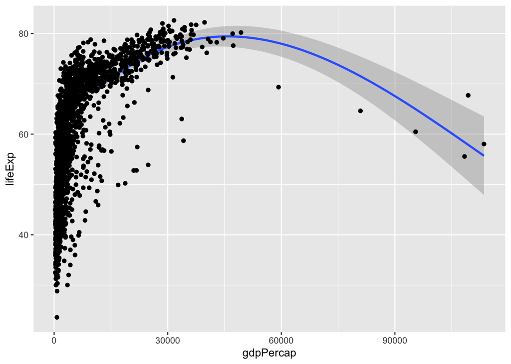

```r
# place appropriate r syntaxes to draw part a
library(gapminder)
library(ggplot2)
library(tidyverse)
p <- ggplot(data = gapminder, mapping = aes(x = gdpPercap,
                          y = lifeExp))
p + geom_smooth() + geom_point()
```

- 2. Change the mappings in the *aes()* function so that you plot **life expectancy** against **population (pop)** rather than per capita GDP. What does that look like? What does it tell you about the unit of observation in the dataset?

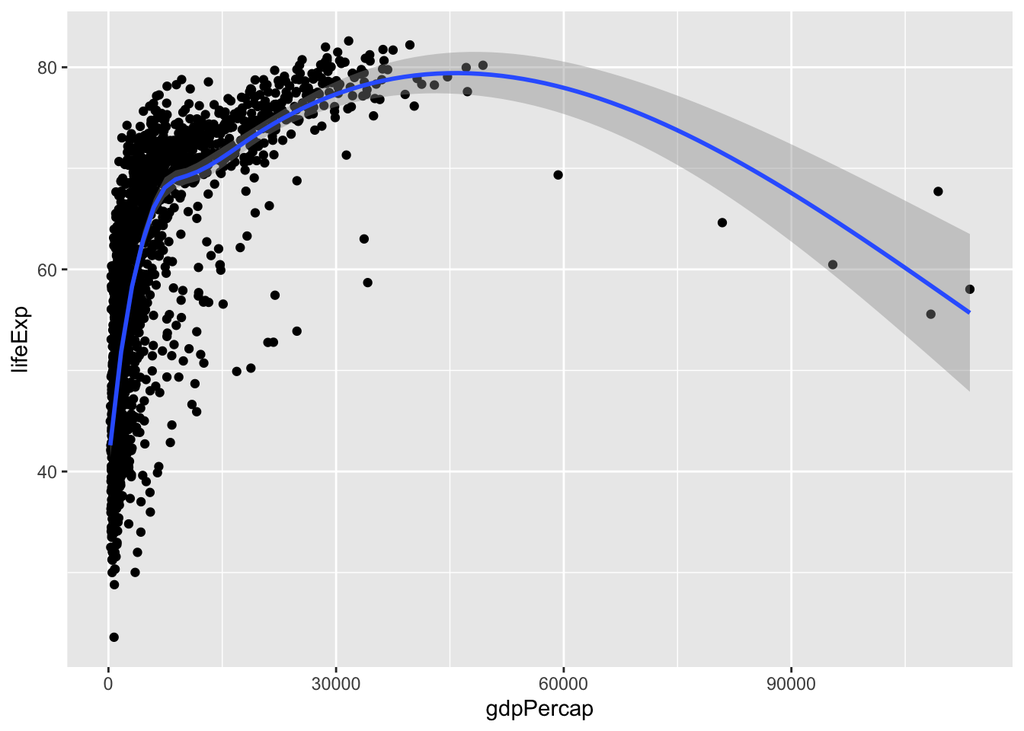

```r
# place appropriate r syntaxes to draw part b plot
library(gapminder)
library(ggplot2)
library(tidyverse)
p <- ggplot(data = gapminder, mapping = aes(x = gdpPercap,
                          y = lifeExp))
p + geom_point() + geom_smooth()
```

- 3. Try some alternative scale mappings. Besides *scale_x_log 10()*, you can try *scale_x_sqrt()*

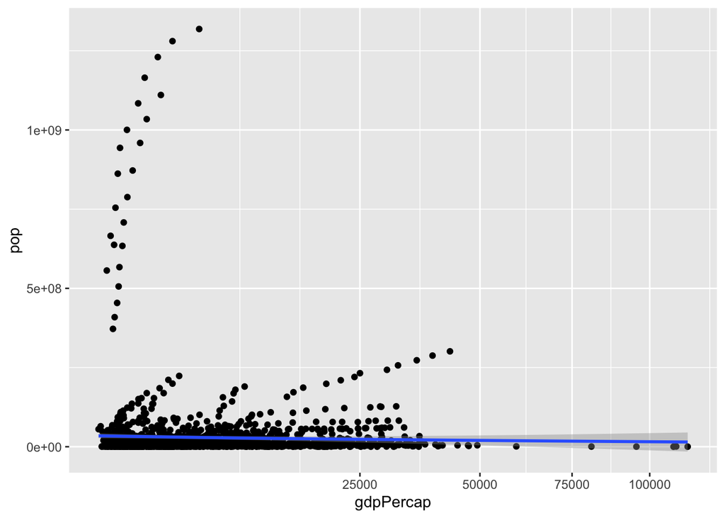

```r
# place appropriate r syntaxes to draw part c plot
library(gapminder)
library(ggplot2)
library(tidyverse)
p <- ggplot(data = gapminder, mapping = aes(x = gdpPercap,
                          y = pop))
p + geom_point() + geom_smooth(method = "gam") + scale_x_sqrt()
```

- 4. What happens if you map *color* to year instead of *continent*?

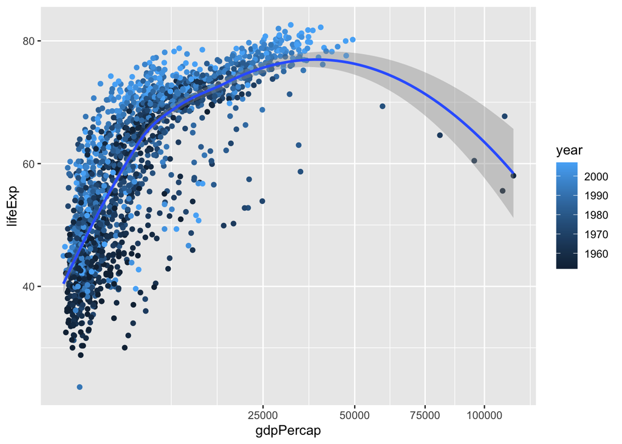

```r
# place appropriate r syntaxes to draw part d plot
library(gapminder)
library(ggplot2)
library(tidyverse)
p <- ggplot(data = gapminder, mapping = aes(x = gdpPercap,
                          y = lifeExp,
                          color = year))
p + geom_point() + geom_smooth(method = "loess") + scale_x_sqrt()
```

Is the result what you expected? Think about what class of object year is. Remember you can get a quick look at the top of the data, which includes some shorthand information on the class of each variable, by typing *gapminder.*

- 5. Instead of mapping *color = year* in part d, what happens if you try *color = factor(year)*?

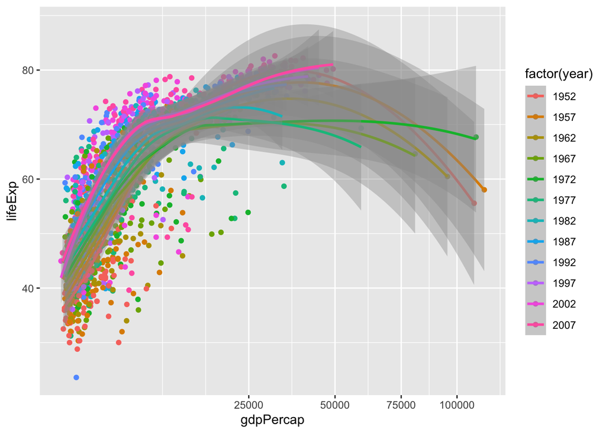

```r
# place appropriate r syntaxes to draw part e plot
library(gapminder)
library(ggplot2)
library(tidyverse)
p <- ggplot(data = gapminder, mapping = aes(x = gdpPercap,
                          y = lifeExp,
                          color = factor(year)))
p + geom_point() + geom_smooth(method = "loess") + scale_x_sqrt()
```